# Daily Options Trade Planning

Adrian Coles

2022-03-23

## Import and Process Market Data

Historical market data from 2012-03-25 to 2022-03-22 are considered in the generation of today’s report.

## Likely Market Direction

**Opening Bell**

Today is likely to be a **bearish** day!

**Reference Price:** 4512

**Opening Price:** 4489

**Opening Gap:** -0.51%

**Note:** A gap in this direction and of this magnitude suggests that there is a **94.4%** chance of the market closing in the **red** today.

**Closing Bell**

**Closing Price:** NA

**Actual Percent Change at Close:** NA%

**Was My Directional Prediction Correct?**: NA

## Suggested Initial Strikes for Today

Given our data-driven assumption on the likely direction of the market, my suggested initial strikes for today are provided in the table below.

The strikes from Method 1 are determined by the desired level of risk tolerance for initial strikes which is **0.1**.

The strikes from Method 2 are based on my proprietary system for Method 2 which is intended to provide conservative strikes.

The strikes from Method 3 are user-defined.

| Method | Strikes | % Change | P(S) |
| --- | --- | --- | --- |
| Method 1: Short Put | 4431 | -1.80 | 0.90 |
| Method 1: Short Call | 4575 | 1.40 | 0.90 |
| Method 2: Short Put | 4429 | -1.85 | 0.91 |
| Method 2: Short Call | 4582 | 1.55 | 0.92 |
| Method 3: Short Put | 4425 | -1.93 | 0.93 |
| Method 3: Short Call | 4535 | 0.51 | 0.68 |

## Daily Trade Tracker

This section records today’s trading activity.

- Day of Week: Wednesday
- Was trade made today: Yes

**Initial Trade Placed:**

- Time: 0935
- Type: Iron Condor
- Initial Short Put Strike: 4425
- Initial Short Call Strike: 4535

**Adjustments:**

- Adjustments Made: No
- Number of Adjustments Made: 0
- Adjusted Short Put Strike:
- Adjusted Short Call Strike:

**Protect My Battleship:**

- Current Strike Range (% Change): [ -1.93, 0.51 ]
- Current Strikes: [ 4425, 4535 ]
- **Maneuver Range (% Change): [ -1.63, 0.21 ]**
- **Recommended New Strike Positions: [ 4411, 4549 ]**

*When to Let My Own Battleship Sink*

- Original Max Loss: 4.25
- 1/2 Original Max Loss: 2.125
- **Sink Battle Ship (i.e., last ditch buy back price): 2.875**

**Daily P/L**

- Number of Contracts: 1
- Initial Premium Collected (per contract): 0.75
- Additional Premium Collected (per contract): 0
- Total Premium Collected (per contract): 0.75
- Buy Back Price: 0
- Initial ROI Target: 17.6%
- Adjusted ROI Target: 17.6%
- Final ROI at Close/Expiration: 17.6%

## Preparing to Defend Today’s Position

It’s possible that the market may move against my strike. If so, the table below provides safe adjustments.

**Note:** Safe implies that the historical market data suggests that there is **> 95% chance** that the market will close above the new floor or below the new ceiling after adjustment.

| Down Side Breach | Adjusted Ceiling | Adjusted Ceiling Strike | Up Side Breach | Adjusted Floor | Adjusted Floor Strike |
| --- | --- | --- | --- | --- | --- |
| < -0.2% | 1.4% | 4575 | > 0.2% | -1.6% | 4440 |
| < -0.75% | 0.8% | 4548 | > 0.75% | -0.9% | 4471 |
| < -1% | 0.7% | 4544 | > 1% | -0.6% | 4485 |
| < -1.25% | 0.6% | 4539 | > 1.25% | -0.5% | 4489 |
| < -1.5% | 0.4% | 4530 | > 1.5% | 0% | 4512 |
| < -1.75% | 0.1% | 4517 | > 1.75% | 0.3% | 4526 |
| < -2% | -0.1% | 4507 | > 2% | 0.8% | 4548 |
| < -2.25% | -0.2% | 4503 | > 2.25% | 2% | 4602 |
| < -2.5% | -0.2% | 4503 | > 2.5% | 2.3% | 4616 |

## Understanding the Nature of the S&P 500

The distribution of the historical market data is displayed in the histogram below.

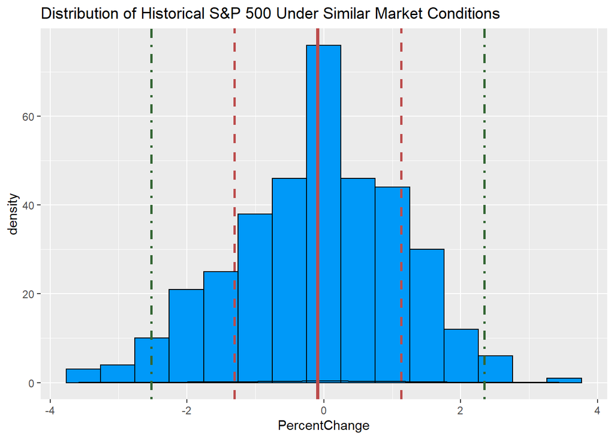

```
##     Min.  1st Qu.   Median     Mean  3rd Qu.     Max.
## -3.59200 -0.83375 -0.01800 -0.08945  0.76650  3.43400
```

**Insights from the Visualizing These Data**

- These data are not normal. They are skewed to the downside.
- History suggests that the extreme downside moves happen more frequently than extreme upside moves.
- Historically, there is more risk on the downside, which suggests there is more premium to collect on the downside.
- More insights will be added soon.